# 1. Overview of sftrack

## Definitions of movement data

We start by defining the main objects that `sftrack` is dealing with. At the top level, there is a **path**, i.e. the real-world (continuous) curve made by moving objects (Fig. 1).

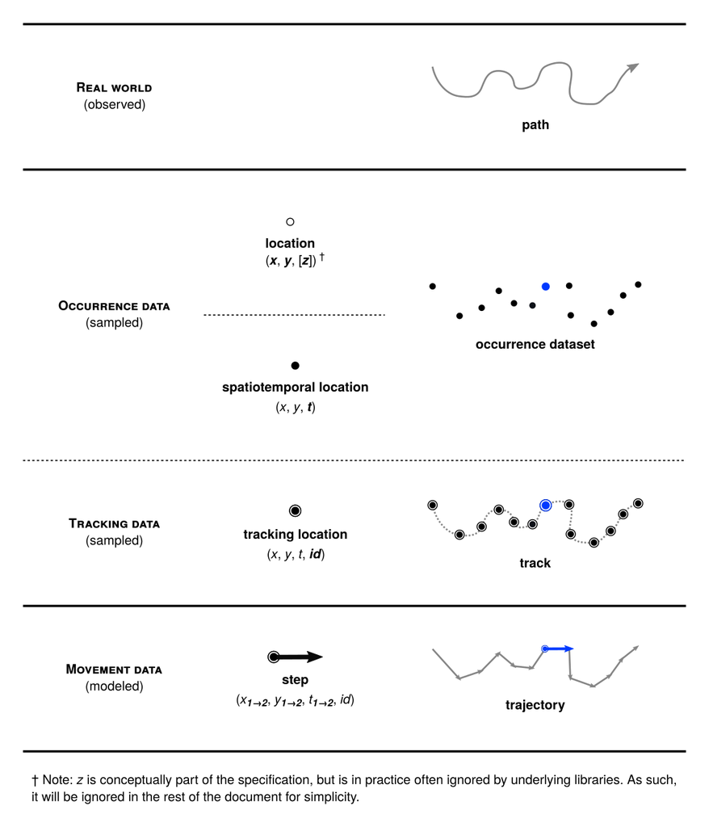

Fig.1: Glossary introducing the main concepts.

In practice, this curve is sampled (recorded) at discrete times to collect **locations**, with or without temporal attributes (think of non-invasive monitoring of animals such as snow tracks vs. direct observations), i.e. in the form of $(x, y)$ or $(x, y, t)$ coordinates. Taken together, locations form the bulk of **occurrence datasets**, such as the massive amount of biodiversity data found on [Global Biodiversity Information Facility (GBIF)](https://www.gbif.org/).

If the organism monitored is known and identified ($id$ attribute), we can collect **tracking locations** (Fig. 1), i.e. $(x, y, t, id)$ coordinates. An ordered series of tracking locations together are in turn the vertices of a **track**. A track is thus composed of a series of locations, i.e. the “complete spatio-temporal record of a followed organism, from the beginning to the end of observations”[^1]. Note that $id$ can be further refined as a general grouping factor (e.g. collar, season, behavior, etc.), which basically split tracking data into sub-tracks.

Finally, tracking data can be modeled considering the temporal autocorrelation between successive locations as part of the movement information[^2]. The most common approach for that purpose is based on a model of **steps** (Fig. 1), defined as straight-line segments between two successive tracking locations. Treating movement steps as straight lines is of course an idealization, and the most parsimonious approach (other complex approaches exist in some fields, such as splines and Bezier curves), but at sufficient resolution, no significant information is lost. A sequence of steps from the same individual (not necessarily connected) finally forms a **trajectory**.

### Tracking and movement data analyses

Because of the dual nature of tracking and movement data, each data type allows different analyses based on the underlying geometric representation (points vs. steps). The following table summarizes in which case the use of tracking vs. movement data is appropriate:

Table 1: Overview of applications based on tracking and movement data.

| Data | Tracking data | Movement data |
| --- | --- | --- |
| Geometric representation | Points | Steps |
| Applications | Home ranges | Random walks |
|  | Resource selection functions | Step selection functions |
|  | K-select | typical Hidden-Markov models and State-space models |
|  |  | typical segmentation methods |
|  |  | First passage time and Residence time |

While this is out of the scope of the `sftrack` package to provide methods for these space use analyses, the package however provide the underlying infrastructure for each case, and a few tools to handle movement of both living organisms and inanimate objects.

## A conceptual model for movement

To organize these elements of data and how they relate to one another and to properties of the real world entities (here a moving object), we followed the methodology for conceptual modeling of geographic information that is specified in the International Standards (ISO/TC 211), which relies on a standard conceptual model specified in Unified Modeling Language (UML)[^3].

### Tracking locations

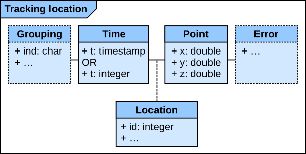

Fig. 2: The location model.

Additionally, “grouping” information can be provided for the location: this needs to be *a minima* the individual (`ind`), e.g. the actual moving object (for instance an animal), but can also be extended to other hierarchical level of the data, such as the year, the grouping, the movement behavior, etc.

Spatial points are never exact and can be characterized by an error. Typically, GPS and Argos data will provide information on the quality of the location, such as satellite data or dilution of precision (for GPS data). The challenge with this information on the error is the complete lack of standardization — as such, this will be left open for the time being.

Finally, a tracking location can also include any information at the level of the point, such as environmental data measured at the location (e.g. land cover).

### Tracking data

Tracking data, in the form of **tracks**, is a series of **tracking locations**. This can be modeled as a collection of tracking locations, unique and ordered in time by individual. As such, locations are the vertices of a single track object; conversely, all locations can be directly extracted from a single track (without any loss of information). The strong constraint on time is necessary and sufficient to organize the data in a track.

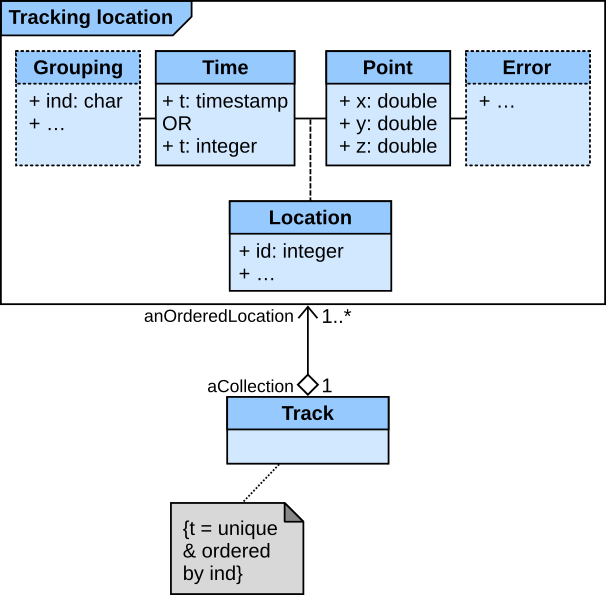

Fig. 3: The track model.

### Steps

A **step** is specifically defined as the straight-line segment connecting two successive **tracking locations**. In other words, it takes two and only two locations to define a step, with the constraints that they belong to the same grouping level (individual in its simplest form), and that the second location comes temporally after the first one.

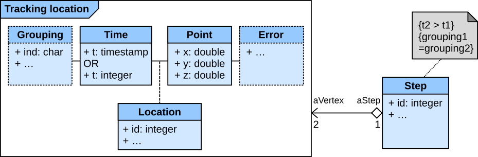

Fig. 4: The step model.

Note that a step can also include information at the level of the line segment. This can be for instance the amount of forest along the step, or the movement rate (i.e. speed).

### Trajectories

Similarly to tracks, **trajectories** are defined by a series of **steps**. A trajectory is thus modeled as a collection of steps, unique and ordered in time by individual. As such, steps are the vertices of a single trajectory object; conversely, all steps can be directly extracted from a single trajectory (without any loss of information). The strong constraint on time is necessary and sufficient to organize the data in a trajectory.

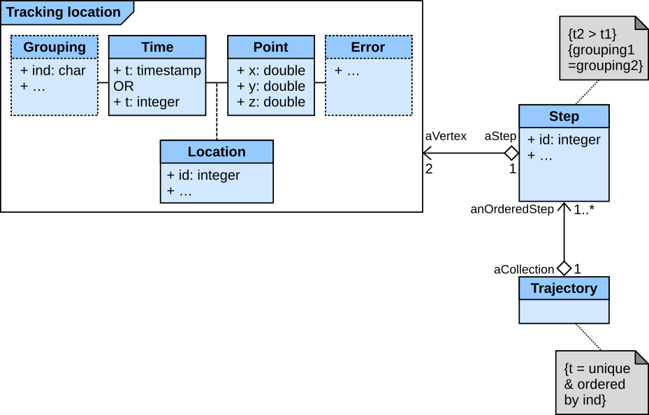

Fig. 5: The trajectory model.

Given the double equivalence between tracking locations and tracks, on the one hand, and steps and trajectories, on the other hand, it follows that there is also a direct equivalence between a track and a trajectory (based on the same movement data); lossless conversion is possible in both directions.

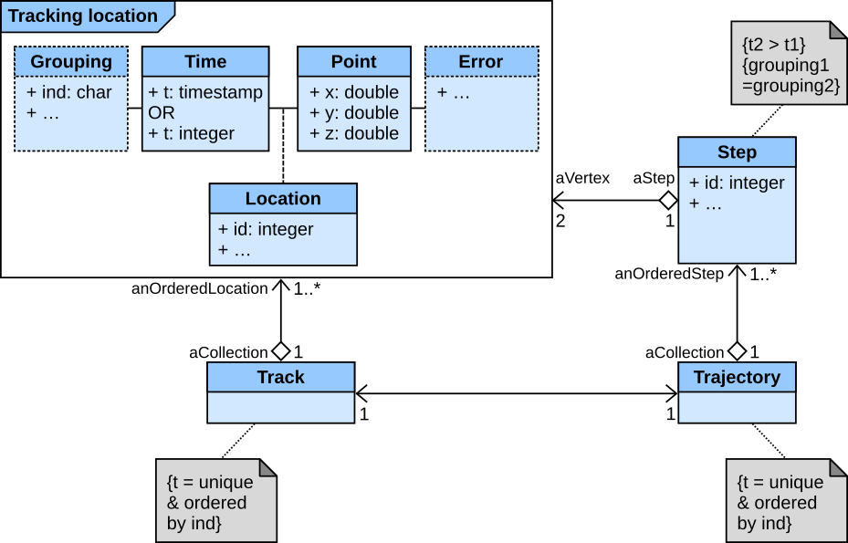

Fig. 6: Full model.

## Implementation in the `sftrack` package

The `sftrack` package deals with all elements presented above, specifically **tracks** and **trajectories**. We’ll begin with a brief overview of an `sftrack` object. An `sftrack` object is a data object that describes the movement of a subject, it has $(x,y)$ coordinates (sometimes $z$), some measurement of time $t$ (clock time or a sequence of integers), and some grouping variable that identifies the subjects. For the spatial aspects of `sftrack`, we are using the package `sf`, a powerful tool that lets us quickly calculate spatial attributes and plot with ease with its full integration with `rgdal`.

An `sftrack` object has 4 parts to it, 3 of which are required:

- **Geometry**: This is stored as an `sfc` object from `sf`. Accepts $(x,y,z)$ coordinates.
- **Group**: This is the grouping variables, which contains at minimum an `id` field to identify the subject. Grouping variables can be turned on at various stages based on the ‘active’ grouping, allowing for the column to be more dynamic than a standard grouping column.
- **Time**: Either a POSIX time object or an integer.
- **Error**: (optional). This is the field with error data in it. At present the column name is being stored as an attribute, but it does not have any real functionality yet.

There are two different classes of objects: `sftrack` for **tracks**, `sftraj` for **trajectories**.

### `sftrack` objects

An `sftrack` object stores tracking data (set of **tracks**) in a `data.frame`, where the geometries are stored as a `POINT` for each row.

```
## Sftrack with 6 features and 10 fields (3 empty geometries)
## Geometry : "geometry" (XY, crs: WGS 84)
## Timestamp : "timestamp" (POSIXct in UTC)
## Groupings : "sft_group" (*id*)
## -------------------------------
##   animal_id latitude longitude           timestamp height hdop vdop fix
## 1   TTP-058       NA        NA 2019-01-19 00:02:30     NA  0.0  0.0  NO
## 2   TTP-058 26.06945 -80.27906 2019-01-19 01:02:30      7  6.2  3.2  2D
## 3   TTP-058       NA        NA 2019-01-19 02:02:30     NA  0.0  0.0  NO
## 4   TTP-058       NA        NA 2019-01-19 03:02:30     NA  0.0  0.0  NO
## 5   TTP-058 26.06769 -80.27431 2019-01-19 04:02:30    858  5.1  3.2  2D
## 6   TTP-058 26.06867 -80.27930 2019-01-19 05:02:30    350  1.9  3.2  3D
##       sft_group                   geometry
## 1 (id: TTP-058)                POINT EMPTY
## 2 (id: TTP-058) POINT (-80.27906 26.06945)
## 3 (id: TTP-058)                POINT EMPTY
## 4 (id: TTP-058)                POINT EMPTY
## 5 (id: TTP-058) POINT (-80.27431 26.06769)
## 6 (id: TTP-058)  POINT (-80.2793 26.06867)
```

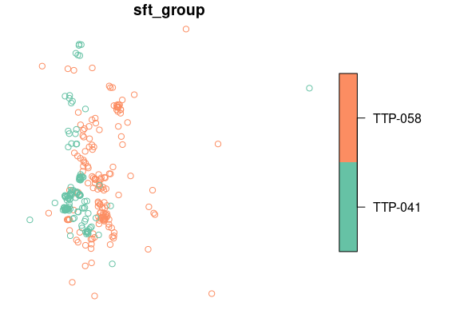

### `sftraj` object

An `sftraj` object stores movement data (set of **trajectories**) in a `data.frame`, where the geometries are stored as a `LINESTRING` for each row. The linestring is a line built from the two points at $t_1 → t_2$. This means that when an `sftraj` object is modified the steps likely need to be recalculated. Internally, anytime the active group is changed, then the geometry is recalculated.

```
## Sftraj with 6 features and 10 fields (3 empty geometries)
## Geometry : "geometry" (XY, crs: WGS 84)
## Timestamp : "timestamp" (POSIXct in UTC)
## Grouping : "sft_group" (*id*)
## -------------------------------
##   animal_id latitude longitude           timestamp height hdop vdop fix
## 1   TTP-058       NA        NA 2019-01-19 00:02:30     NA  0.0  0.0  NO
## 2   TTP-058 26.06945 -80.27906 2019-01-19 01:02:30      7  6.2  3.2  2D
## 3   TTP-058       NA        NA 2019-01-19 02:02:30     NA  0.0  0.0  NO
## 4   TTP-058       NA        NA 2019-01-19 03:02:30     NA  0.0  0.0  NO
## 5   TTP-058 26.06769 -80.27431 2019-01-19 04:02:30    858  5.1  3.2  2D
## 6   TTP-058 26.06867 -80.27930 2019-01-19 05:02:30    350  1.9  3.2  3D
##       sft_group                       geometry
## 1 (id: TTP-058)                    POINT EMPTY
## 2 (id: TTP-058)     POINT (-80.27906 26.06945)
## 3 (id: TTP-058)                    POINT EMPTY
## 4 (id: TTP-058)                    POINT EMPTY
## 5 (id: TTP-058) LINESTRING (-80.27431 26.06...
## 6 (id: TTP-058) LINESTRING (-80.2793 26.068...
```

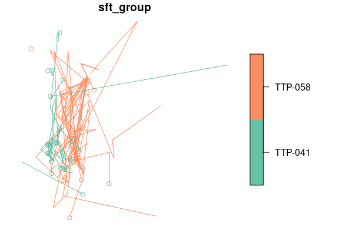

[^1]: Turchin, P. (1998). Quantitative analysis of movement: measuring and modeling population redistribution in animals and plants. Sinauer Associates, Sunderland, MA, USA.
[^2]: Martin, J., Tolon, V., Van Moorter, B., Basille, M., & Calenge, C. (2009). On the use of telemetry in habitat selection studies. In D. Barculo, & J. Daniels (Eds.), Telemetry: Research, Technology and Applications (pp. 37–55). Nova Science Publishers Inc.
[^3]: Roswell, C. (2011). Modeling of geographic information. Springer Handbook of Geographic Information, 3–6. http://dx.doi.org/10.1007/978-3-540-72680-7_1